# 市场观察

2017/07/25

## A、指数估值

### (a1)动态市盈率、市净率

核心指数成分股近18个月的动态市盈率及动态市净率中位数走势如下图所示：

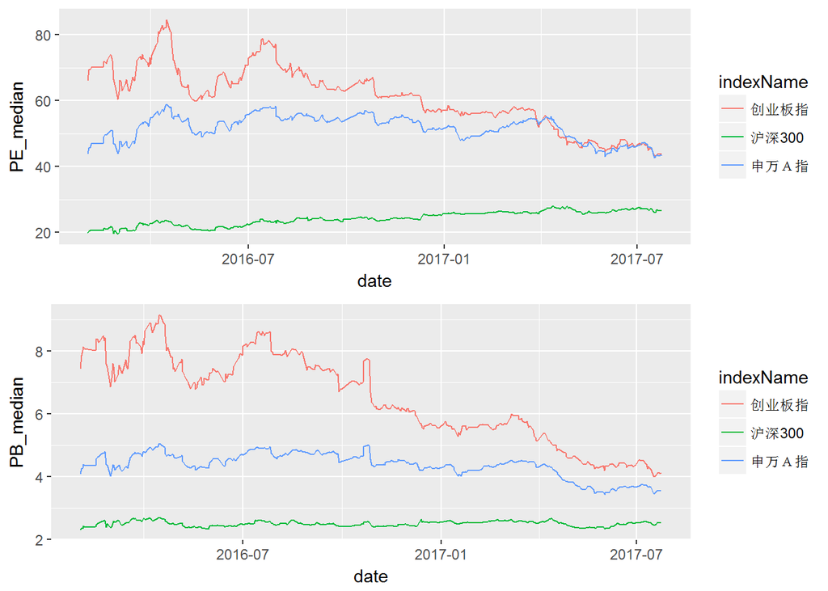

### (a2)动态市盈率、市净率百分位

核心指数近18个月的动态市盈率百分位及动态市净率百分位走势如下图所示：

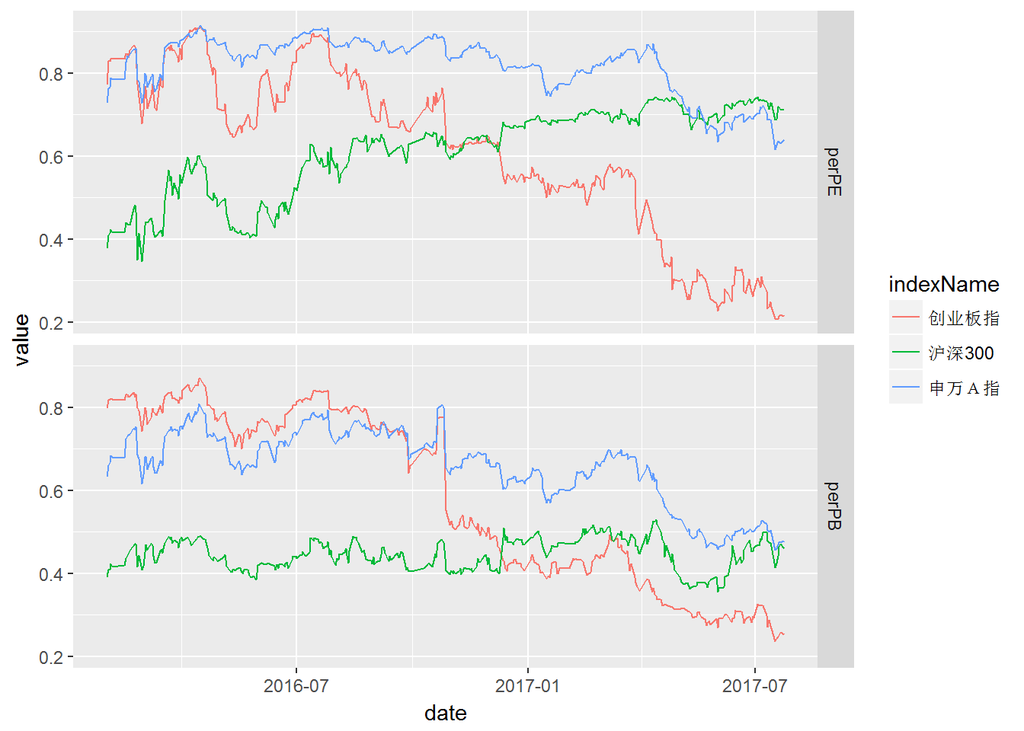

### (a3)指数估值概览

纳入观察的指数最新的估值情况如下表，根据市盈率和市净率分位数均值降序排列。

| 指数代码 | 指数简称 | 日期 | 动态市盈率 | 市盈率百分位 | 动态市净率 | 市净率百分位 |
| --- | --- | --- | --- | --- | --- | --- |
| EI000819 | 有色金属 | 2017-07-24 | 62.3 | 84% | 3.6 | 64% |
| EI000979 | 大宗商品 | 2017-07-24 | 37.9 | 71% | 2.7 | 58% |
| EI000300 | 沪深300 | 2017-07-24 | 26.7 | 71% | 2.5 | 46% |
| EI399330 | 深证100 | 2017-07-24 | 33.6 | 70% | 3.4 | 43% |
| EI801003 | 申万Ａ指 | 2017-07-24 | 43.5 | 64% | 3.6 | 48% |
| EI399959 | 军工指数 | 2017-07-24 | 80.4 | 53% | 4.0 | 49% |
| EI399005 | 中小板指P | 2017-07-24 | 37.9 | 52% | 4.4 | 37% |
| EI000934 | 中证金融 | 2017-07-24 | 19.6 | 67% | 1.8 | 19% |
| EI000905 | 中证500 | 2017-07-24 | 36.0 | 49% | 2.8 | 31% |
| EI000016 | 上证50 | 2017-07-24 | 17.2 | 55% | 1.7 | 20% |
| EI000922 | 中证红利 | 2017-07-24 | 16.5 | 43% | 1.7 | 27% |
| EI000932 | 中证消费 | 2017-07-24 | 31.1 | 45% | 3.7 | 23% |
| EI000998 | 中证TMT | 2017-07-24 | 40.1 | 33% | 3.5 | 27% |
| EI000827 | 中证环保 | 2017-07-24 | 34.6 | 24% | 3.0 | 26% |
| EI399006 | 创业板指 | 2017-07-24 | 43.8 | 22% | 4.1 | 25% |
| EI000933 | 中证医药 | 2017-07-24 | 32.2 | 17% | 3.6 | 1% |

### (a4)另类估值

我国10年期国债收益率、金银比价、金油比价，2000年以来的历史百分位如下图所示：

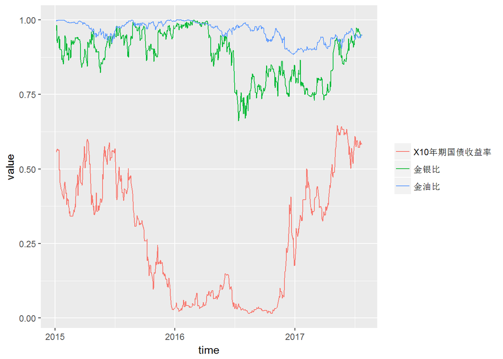

## B、基差及市场情绪

### (b1)基差走势

三大股指期货合约基差走势如下图，其中当月合约和次月合约年化基差百分比波动较大，仅展示合约基差百分比，当季合约和次季合约展示基差年化百分比：

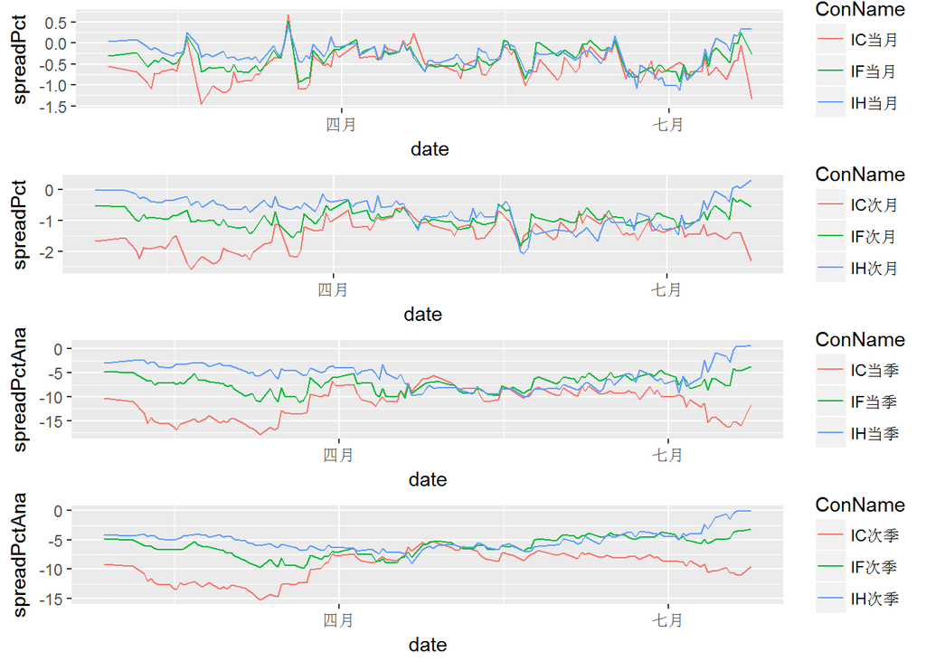

### (b2)基差概况

三大股指期货连续合约基差概况如下表，近月合约临近到期日，年化基差百分比数据波动较大：

| 日期 | 合约代码 | 合约收盘价 | 指数收盘价 | 基差 | 基差百分比 | 年化基差百分比 |
| --- | --- | --- | --- | --- | --- | --- |
| 2017-07-24 | IC1708 | 6083.8 | 6167.1 | -83.3 | -1.4% | -21.6% |
| 2017-07-24 | IC1709 | 6024.2 | 6167.1 | -142.9 | -2.3% | -17.1% |
| 2017-07-24 | IC1712 | 5894.8 | 6167.1 | -272.3 | -4.4% | -11.6% |
| 2017-07-24 | IC1803 | 5796.6 | 6167.1 | -370.5 | -6.0% | -9.5% |
| 2017-07-24 | IF1708 | 3733.0 | 3743.5 | -10.5 | -0.3% | -4.2% |
| 2017-07-24 | IF1709 | 3722.4 | 3743.5 | -21.1 | -0.6% | -3.9% |
| 2017-07-24 | IF1712 | 3689.2 | 3743.5 | -54.3 | -1.4% | -3.7% |
| 2017-07-24 | IF1803 | 3669.2 | 3743.5 | -74.3 | -2.0% | -3.1% |
| 2017-07-24 | IH1708 | 2663.0 | 2654.4 | 8.6 | 0.3% | 4.8% |
| 2017-07-24 | IH1709 | 2662.8 | 2654.4 | 8.4 | 0.3% | 2.2% |
| 2017-07-24 | IH1712 | 2663.0 | 2654.4 | 8.6 | 0.3% | 0.8% |
| 2017-07-24 | IH1803 | 2655.8 | 2654.4 | 1.4 | 0.1% | 0.1% |

### (b3)市场情绪(provided by han.qian)

市场情绪记录近60天每天自然涨跌停(剔除一字板)、创60日新高新低、多头排列空头排列(均线组合5,30,60,120)的股票数。

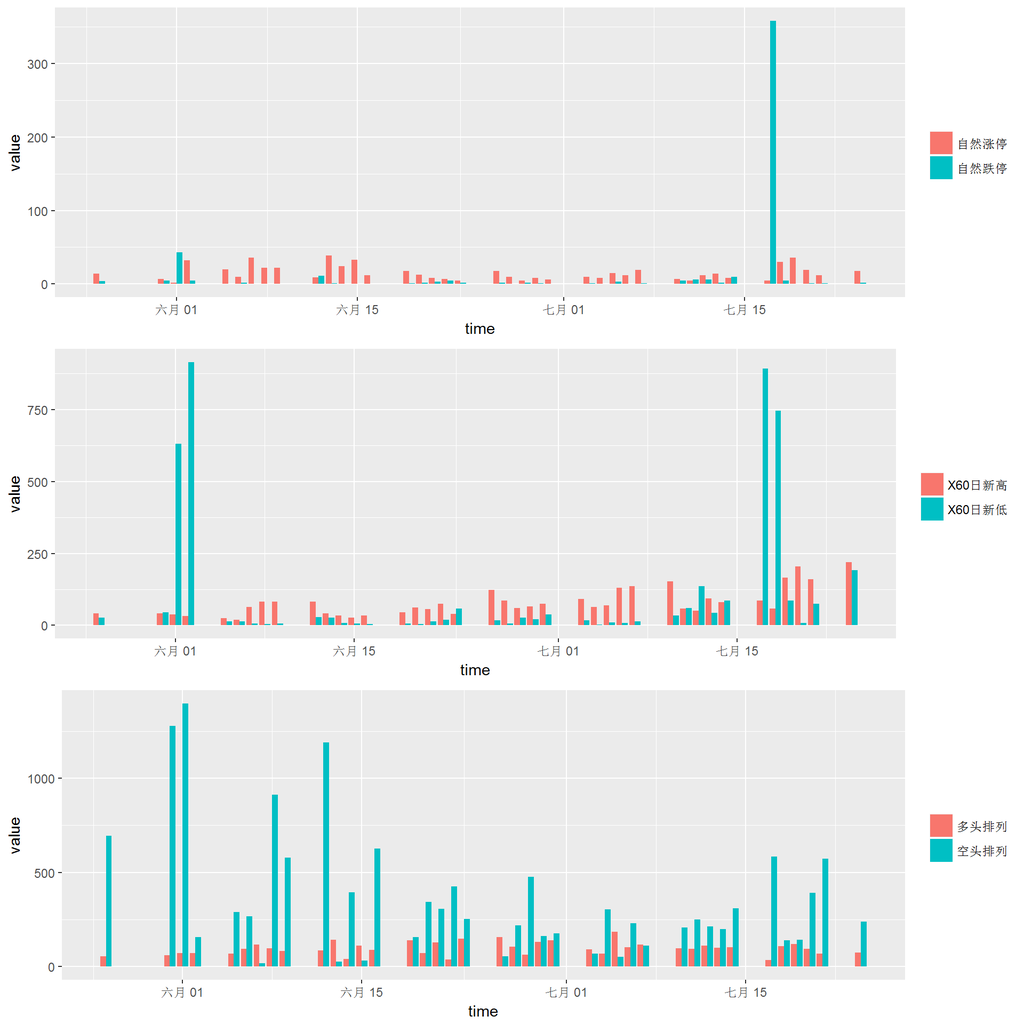

## C、套利和事件

### (c1)复牌股票套利

近两天复牌股票套利情况如下表：

[1] “No Arbitrage!”

### (c2)解禁

解禁分成两个部分，定增解禁和IPO解禁，涨跌幅记录是过去十个交易日的股票涨跌幅和对应行业指数涨跌幅。伴随着去年下半年IPO逐步正常化，今后IPO解禁给市场造成的抛压会持续存在，所以纳入观察。近期定增解禁的股票情况如下表。

| 股票代码 | 股票简称 | 解禁日 | 解禁数量 | 解禁百分比 | 区间涨跌幅 | 所属行业指数 | 行业指数涨跌幅 |
| --- | --- | --- | --- | --- | --- | --- | --- |
| EQ000605 | 渤海股份 | 2017-07-26 | 0.72 | 58% | -7.5% | 申万公用事业 | -3.8% |
| EQ000408 | 藏格控股 | 2017-07-27 | 0.61 | 24% | 0.9% | 申万商业贸易 | -1.8% |
| EQ600864 | 哈投股份 | 2017-07-28 | 5.02 | 92% | 4.1% | 申万非银金融 | 2.8% |
| EQ000040 | 东旭蓝天 | 2017-07-28 | 5.94 | 127% | -9.0% | 申万房地产 | -0.2% |
| EQ002157 | 正邦科技 | 2017-07-31 | 4.96 | 36% | -0.2% | 申万农林牧渔 | -4.4% |
| EQ600185 | 格力地产 | 2017-08-04 | 4.42 | 27% | -0.6% | 申万房地产 | -0.2% |
| EQ601901 | 方正证券 | 2017-08-08 | 19.42 | 31% | -6.5% | 申万非银金融 | 2.8% |

近期IPO解禁的股票情况如下表。

| 股票代码 | 股票简称 | 解禁日 | 解禁数量 | 解禁百分比 | 区间涨跌幅 | 所属行业指数 | 行业指数涨跌幅 | 上市日 |
| --- | --- | --- | --- | --- | --- | --- | --- | --- |
| EQ002806 | 华锋股份 | 2017-07-26 | 0.22 | 65% | 0.0% | 申万有色金属 | 4.3% | 2016-07-26 |
| EQ300523 | 辰安科技 | 2017-07-26 | 0.64 | 178% | -10.3% | 申万计算机 | -7.3% | 2016-07-26 |
| EQ300525 | 博思软件 | 2017-07-26 | 0.26 | 154% | -17.0% | 申万计算机 | -7.3% | 2016-07-26 |
| EQ603322 | 超讯通信 | 2017-07-28 | 0.12 | 62% | -10.4% | 申万通信 | -4.3% | 2016-07-28 |
| EQ300389 | 艾比森 | 2017-07-31 | 2.25 | 242% | -9.8% | 申万电子 | -1.3% | 2014-08-01 |
| EQ300390 | 天华超净 | 2017-07-31 | 1.50 | 113% | -13.0% | 申万电子 | -1.3% | 2014-07-31 |
| EQ300384 | 三联虹普 | 2017-07-31 | 0.91 | 171% | -3.2% | 申万计算机 | -7.3% | 2014-08-01 |
| EQ603126 | 中材节能 | 2017-07-31 | 3.92 | 180% | 0.0% | 申万公用事业 | -3.8% | 2014-07-31 |
| EQ002728 | 特一药业 | 2017-07-31 | 1.35 | 223% | -4.7% | 申万医药生物 | -3.7% | 2014-07-31 |
| EQ603111 | 康尼机电 | 2017-08-01 | 3.52 | 92% | -4.3% | 申万机械设备 | -3.6% | 2014-08-01 |
| EQ603663 | 三祥新材 | 2017-08-01 | 0.16 | 46% | -14.1% | 申万有色金属 | 4.3% | 2016-08-01 |
| EQ300388 | 国祯环保 | 2017-08-01 | 1.23 | 72% | -5.3% | 申万公用事业 | -3.8% | 2014-08-01 |
| EQ300391 | 康跃科技 | 2017-08-01 | 1.05 | 170% | 15.4% | 申万机械设备 | -3.6% | 2014-08-01 |
| EQ300529 | 健帆生物 | 2017-08-02 | 0.64 | 152% | -8.0% | 申万医药生物 | -3.7% | 2016-08-02 |
| EQ300526 | 中潜股份 | 2017-08-02 | 0.17 | 41% | -18.0% | 申万纺织服装 | -3.4% | 2016-08-02 |
| EQ600919 | 江苏银行 | 2017-08-02 | 4.48 | 39% | 4.9% | 申万银行 | 6.9% | 2016-08-02 |
| EQ300528 | 幸福蓝海 | 2017-08-08 | 0.73 | 78% | -12.9% | 申万传媒 | -5.9% | 2016-08-08 |
| EQ603609 | 禾丰牧业 | 2017-08-08 | 4.13 | 99% | -8.8% | 申万农林牧渔 | -4.4% | 2014-08-08 |
| EQ601811 | 新华文轩 | 2017-08-08 | 1.00 | 102% | -4.7% | 申万传媒 | -5.9% | 2016-08-08 |

### (c3)中小板业绩预增预测(provided by han.qian)

中小板规定正式财务报告发布的同时需要发布新一期的业绩预报，比如年报中会包含一季报预告的情况。我们假设公司的盈利状况有动量效应，年报预增的公司一季度也会预增，在正式财务报告发布前20个交易日开始埋伏，然后等正式报告发布日卖出。具体研究参见钱瀚前期的研究。需要注意的是这里的收益率仅做展示，仅仅是每日全部入选股票的平均收益率，并没有做成一个事件组合。

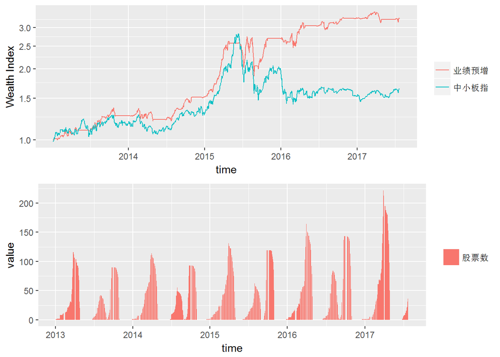

历年收益统计如下表所示。

|  | 业绩预增 | 中小板指 |
| --- | --- | --- |
| 2013-01-04 ~ 2013-12-31 | 26.4% | 17.5% |
| 2014-01-02 ~ 2014-12-31 | 20.3% | 9.7% |
| 2015-01-05 ~ 2015-12-31 | 77.5% | 53.7% |
| 2016-01-04 ~ 2016-12-30 | 21.9% | -22.9% |
| 2017-01-03 ~ 2017-07-24 | 0.2% | 7.6% |
| Cumulative Return | 229.7% | 64.4% |
| Annualized Return | 29.9% | 11.5% |